# Partie 5 : qgam

2023-02-27

## QGAM & prévision en loi

### 5.1 Motivations

Dans les précédantes partie du rapport, nous nous contentions de fournir “la meilleur prévision possible” mais on peut également être amené à vouloir prédire plus que ça. En effet, des problèmes pratique peuvent impliquer de vouloir obtenir une prévision d’un intervalle de confiance que ce soit pour des raisons de gestion de risque ou bien pour des problématiques d’analyse d’événements rares. Voici donc une liste non-exhaustive des raisons d’effectuer des prévisions en loi ce que nous allons faire tout au long de cette partie.

### 5.2 Présentation & une première approche naîve

Comme expliqué dans le paragraphe précédant, ce que l’on cherche à obtenir c’est une prévision des quantiles de la loi qui nous intéresse. Or si l’on se rappelle du fonctionnement des GAMS (cf partie 3), notre model est designé pour produire quelque chose de la forme
$$y_i=X_i\beta + f_1(x_{1,i})+
f_2(x_{2,i},x_{3,i})+...+ f_d(x_{d,i})+\epsilon_i$$
où
$$\epsilon_i \sim
\mathcal{N}(0,\,\sigma^{2})$$
Par conséquent, un model que l’on a naturellement envie de prendre pour prédire la loi qui nous intéresse serait de prendre les quantiles d’une variable d’Espérance la prédiction produite par le GAM et de Variance $\sigma^2$ que l’on obtiendrait en prenant par exemple l’estimateur empirique de la variance sur les données d’entraînement.

Dans cette partie, nous nous sommes limités à une seule heure pour des raisons de calcul qui ont vite tendance à être très élevé avec l’approche que l’on verre en 5.3

Le Gam que l’on regarde est fait à partir de l’equation suivante : Load ~ s(Load.48)+s(Temp_s95)+s(Temp_s99)+s(Temp)+s(toy)+WeekDaysMonday+WeekDaysTuesday+WeekDaysWednesday+WeekDaysThursday+WeekDaysFriday+WeekDaysSaturday

et on peut vérifier que l’hypothèse de normalité des résidus est loin d’être délirante lorsqu’on regarde l’histogramme des résidus qui semble correspondre quasi parfaitement :

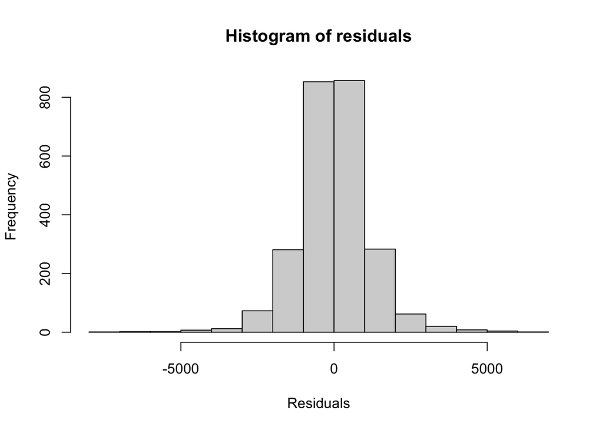

Pour autant, si on s’attarde sur le diagramme quantile/quantile, on remarque que pour les valeurs extrêmes cela est moins vrai.

```
## [1] 1 2
```

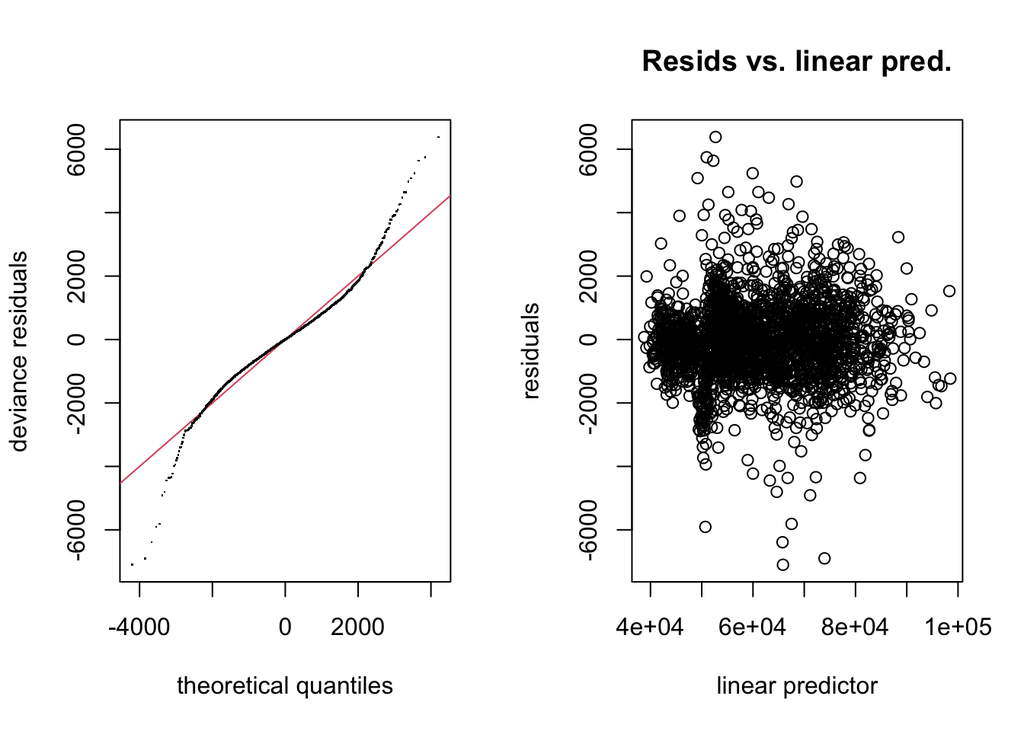

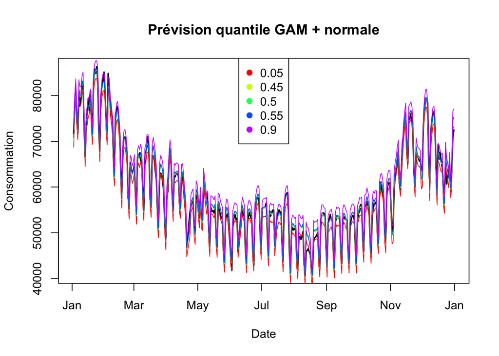

### 5.3 QGAM

Comme évoqué précédemment, le model décrit dans la partie précédante n’est qu’une approche naïve car dans notre cas, c’est clair que la variance ne va pas être la même selon si la consommation est importante ou pas. Par conséquent, nous avons choisi d’utiliser des QGAMs qui est une méthode qui s’affranchit du cadre paramétrique dans lequel les GAMs étaient contraints en utilisant des méthodes de calibrations Bayesiennes (@Manual). Pour ce faire, le model est entraîné à partir d’une fonction de perte classique :

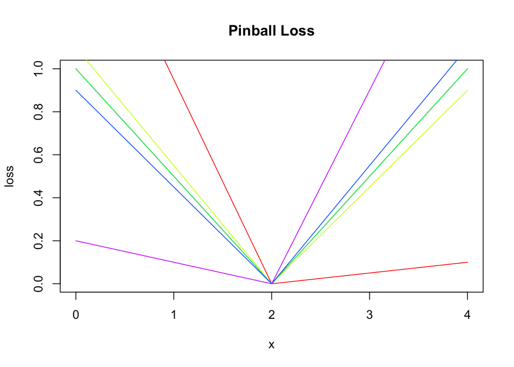

On peut là encore faire le même type de plot que dans la partie 5.2 et on remarque que les tracés ont l’air plus complexes et plus adaptés à la réalité des données.

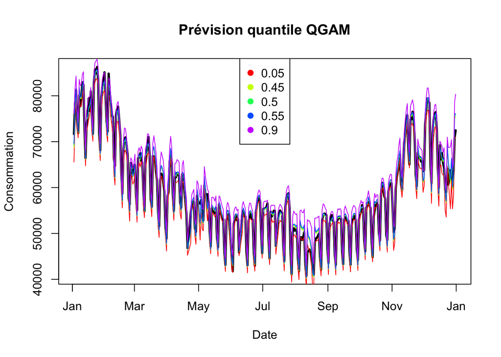

Intuitivement, on se dit que QGAM donne de meilleur résultat que GAM+normale mais reste à trouver un critère qui permet de les comparer. Dans un premier temps nous nous sommes dis que compter le nombre de données du dataset de test qui sont au dessus du quantile q mais cette approche ne mesure pas vraiment ce que l’on veut. Nous avons donc décidé d’utiliser ici uniquement un critère plus pertinent à savoir la pinball loss sur les données d’entraînement et d’afficher le ratio entre les deux méthodes :
$$ratio(quantile) =
\frac{pinball(qgam(quantile))}{pinball(gam_+normale(quantile))}$$

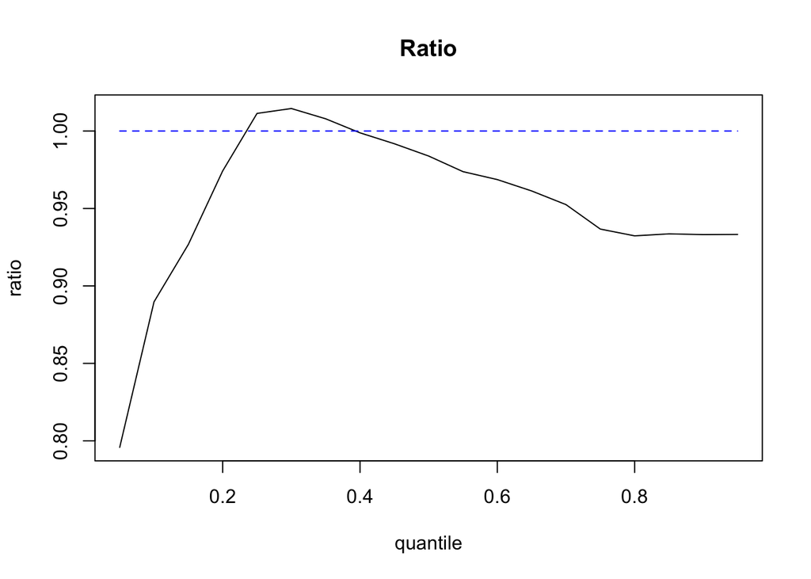

Comme prévu, QGAM donne de meilleur résultat pour environ tous les quantiles. A noter toutefois que pour les quantiles entre 25% et 40% les quantiles de la loi normale donnent des résultats légèrement meilleur (de l’ordre d’1 à 2%) mais cela n’est pas comparable aux écarts allant jusqu’à plus de 10% pour le reste des quantiles (plus les quantiles sont extrêmes plus la différence de performance est grande). Par conséquent, on peut conclure que lorsqu’on s’intéresse aux quantiles extrêmes, QGAM est nécessaire car c’est justement pour ces données extrêmes que l’hypothèse de variance constante n’est plus viable. En revanche, GAM+normale peut être utilisé notamment dans des modèles d’agrégation d’expert puisqu’il est assez performant pour des quantiles proches de la médiane.

### 5.4 Applications (Focus on 90%)

Dans cette dernière sous-partie, nous allons regarder un cas d’application pour un quantile extrême à savoir 90 %. Dans le cas de l’électricité, on peut facilement imaginer des applications pour calibrer le parc électrique de sortes à ce qu’il puisse produire à moindre coût pour des consommations “habituelles”. Dans un premier temps, on affiche les quantiles sur les données de test.

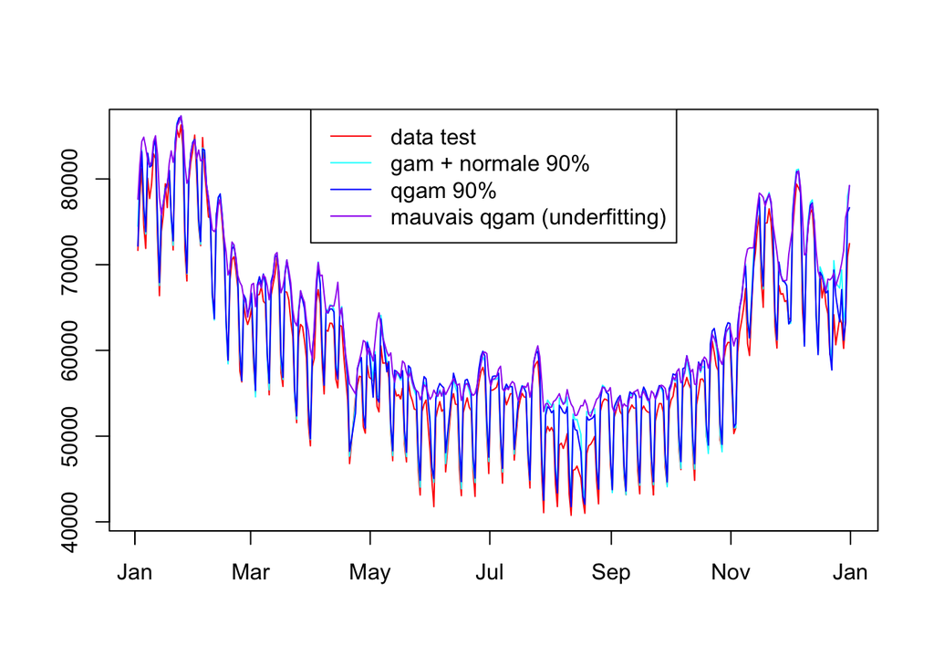

##Référence

@Manual{R-base, title = {qgam: Bayesian Nonparametric Quantile Regression Modeling in R}, author = {{Matteo Fasiolo, Simon N. Wood, Margaux Zaffran, Raphaël Nedellec, Yannig Goude}}, year = {2021}, url = {https://www.jstatsoft.org/article/view/v100i09}, }